# Администрирование локальных сетей

Лабораторная работа №16. Настройка VPN

Илья Колонтырский

Российский университет дружбы народов, Москва, Россия

23.05.2026

# Цели и задачи работы

## Цель лабораторной работы

Получить навыки настройки VPN-туннеля через незащищённое Интернет-соединение.

В работе использовался туннель на основе протокола **GRE**, который позволяет связать удалённые сети поверх существующей IP-инфраструктуры.

## Задачи

- Разместить оборудование сети Университета г. Пиза в логической рабочей области.
- Создать физическую область: город Пиза и здание университета.
- Выполнить первоначальную настройку сетевого оборудования.
- Настроить VLAN и интерфейсы маршрутизатора.
- Создать GRE-туннель между площадками.
- Проверить доступность узлов сети Университета г. Пиза с ноутбука администратора сети «Донская».

# Размещение оборудования

## Логическая схема проекта

В рабочей области Packet Tracer был добавлен участок сети Университета г. Пиза.

В состав сети вошли:

- маршрутизатор **2811**;
- коммутатор **2950-24**;
- оконечное устройство **PC-PT**;
- промежуточное устройство **Repeater-PT**.

## Логическая схема проекта

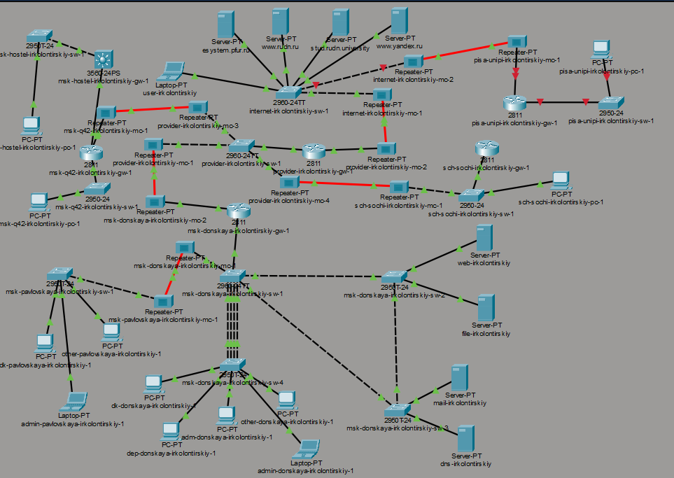

Логическая схема проекта с добавленным участком сети Университета г. Пиза

## Физическая рабочая область

В физической области Packet Tracer были созданы:

- город **Пиза**;
- здание **Университета г. Пиза**;
- физическое размещение сетевого оборудования внутри здания.

## Физическая рабочая область

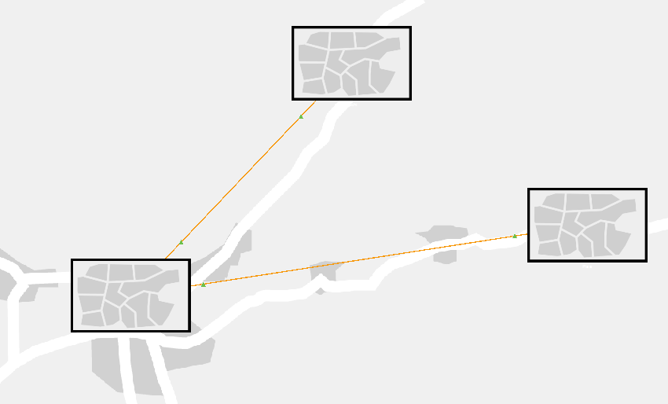

Физическая рабочая область проекта: город Пиза и здание университета

## Размещение оборудования в стойке

[figure not shown]

Размещение оборудования сети Университета г. Пиза в стойке

# Настройка коммутатора

## Первоначальная настройка коммутатора

На коммутаторе **pisa-unipi-irkolontirskiy-sw-1** были настроены:

- имя устройства;
- пароль консольного доступа;
- пароль для линий **VTY 0 4**;
- пароль привилегированного режима;
- локальный пользователь **admin**;
- доменное имя **unipi.edu**;
- SSH-доступ.

## Первоначальная настройка коммутатора

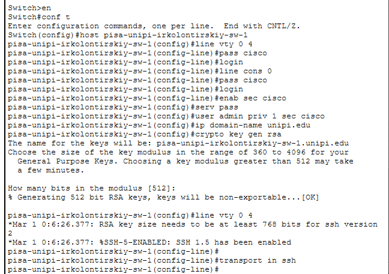

Первоначальная настройка коммутатора сети Университета г. Пиза

## Настройка VLAN и портов

Для локальной сети университета была создана VLAN **401** с именем **unipi-main**.

Настройка портов:

- **FastEthernet0/1** — access-порт VLAN 401;
- **FastEthernet0/24** — trunk-порт к маршрутизатору;
- **Vlan401** — виртуальный интерфейс управления.

## Настройка VLAN и портов

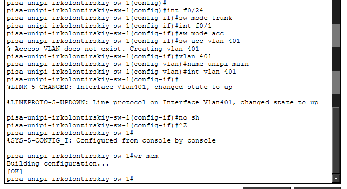

Настройка VLAN 401, access-порта и trunk-порта

# Настройка маршрутизатора

## Первоначальная настройка маршрутизатора

На маршрутизаторе **pisa-unipi-irkolontirskiy-gw-1** были настроены:

- имя устройства;
- консольный доступ;
- VTY-доступ;
- пароль привилегированного режима;
- пользователь **admin**;
- доменное имя **unipi.edu**;
- RSA-ключи;
- доступ по SSH.

## Первоначальная настройка маршрутизатора

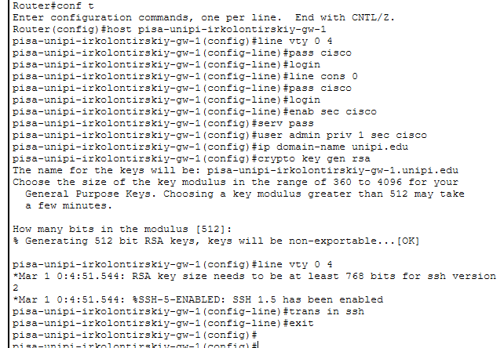

Первоначальная настройка маршрутизатора сети Университета г. Пиза

## Настройка интерфейсов маршрутизатора

Основные интерфейсы маршрутизатора:

- **FastEthernet0/0** — подключение к локальному коммутатору;
- **FastEthernet0/0.401** — подинтерфейс VLAN 401;
- **10.131.0.1/24** — шлюз локальной сети университета;
- **FastEthernet0/1** — внешний интерфейс;
- **192.0.2.20/24** — внешний адрес маршрутизатора.

## Настройка интерфейсов маршрутизатора

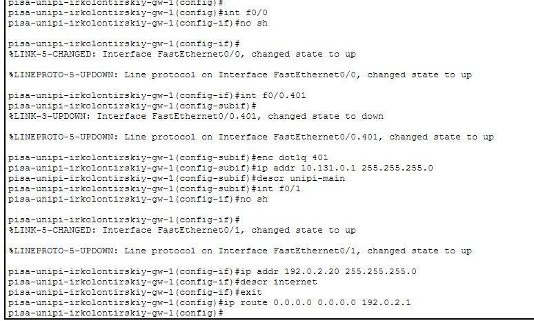

Настройка интерфейсов маршрутизатора и маршрута по умолчанию

# Настройка GRE VPN

## GRE-туннель на стороне Университета г. Пиза

На маршрутизаторе **pisa-unipi-irkolontirskiy-gw-1** был создан туннельный интерфейс **Tunnel0**.

Параметры туннеля:

- IP-адрес — **10.128.255.254/30**;
- tunnel source — **FastEthernet0/1**;
- адрес источника — **192.0.2.20**;
- tunnel destination — **198.51.100.2**;
- протокол — **GRE/IP**.

## GRE-туннель на стороне Университета г. Пиза

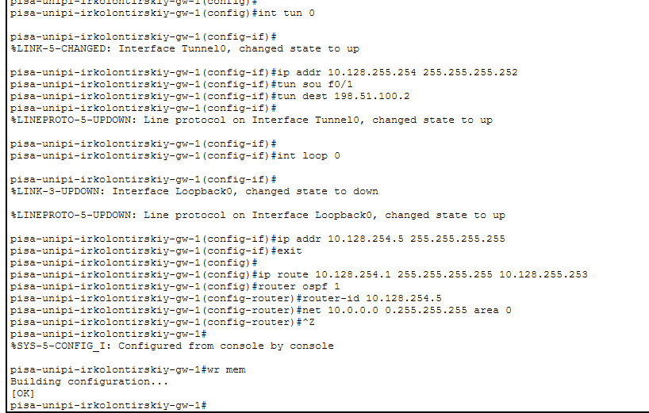

Настройка GRE-туннеля, Loopback0 и OSPF

## Удалённая сторона GRE-туннеля

На маршрутизаторе **msk-donskaya-irkolontirskiy-gw-1** был настроен второй конец туннеля.

Параметры удалённой стороны:

- IP-адрес Tunnel0 — **10.128.255.253/30**;
- tunnel source — **FastEthernet0/1.4**;
- tunnel destination — **192.0.2.20**;
- Loopback0 — **10.128.254.1/32**.

## Удалённая сторона GRE-туннеля

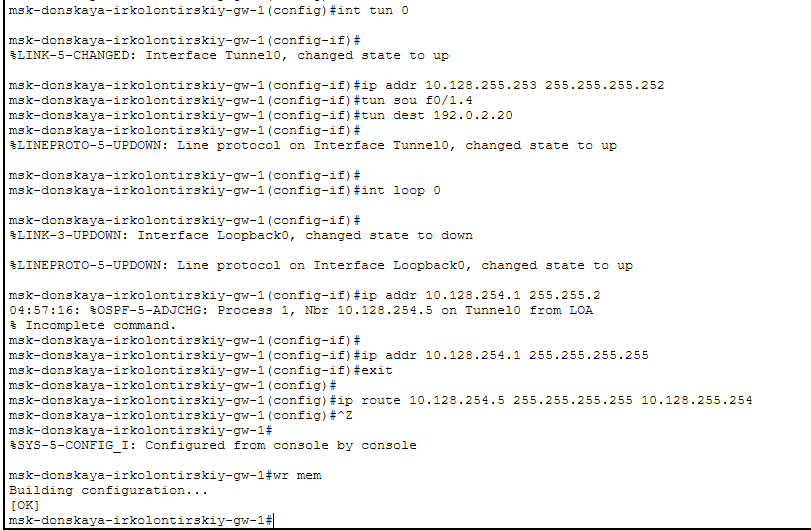

Настройка удалённой стороны GRE-туннеля

## Назначение GRE-туннеля

GRE-туннель используется для передачи трафика между удалёнными площадками поверх существующей IP-сети.

В работе туннель позволил:

- связать сеть Университета г. Пиза с сетью «Донская»;
- передавать трафик между частными адресными пространствами;
- использовать OSPF для обмена маршрутами;
- обеспечить логическую связность удалённых сетей.

# Проверка доступности

## Настройка конечного узла

На компьютере **pisa-unipi-irkolontirskiy-pc-1** были заданы параметры IPv4:

- IP-адрес — **10.131.0.200**;
- маска подсети — **255.255.255.0**;
- шлюз по умолчанию — **10.131.0.1**;
- DNS-сервер — **10.128.0.5**.

## Настройка конечного узла

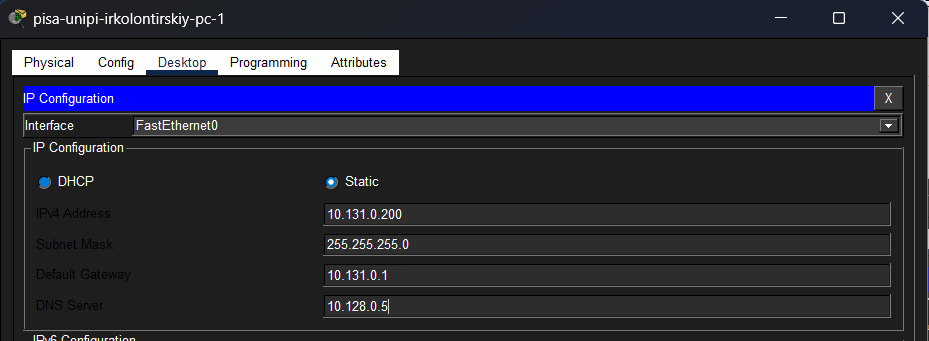

Настройка IP-адреса на компьютере сети Университета г. Пиза

## Проверка ping и tracert

С ноутбука администратора сети «Донская» были выполнены проверки:

- **ping 10.131.0.1** — проверка доступности шлюза сети Университета г. Пиза;
- **ping 10.131.0.200** — проверка доступности конечного узла;
- **tracert 10.131.0.200** — проверка маршрута прохождения пакетов.

## Проверка ping и tracert

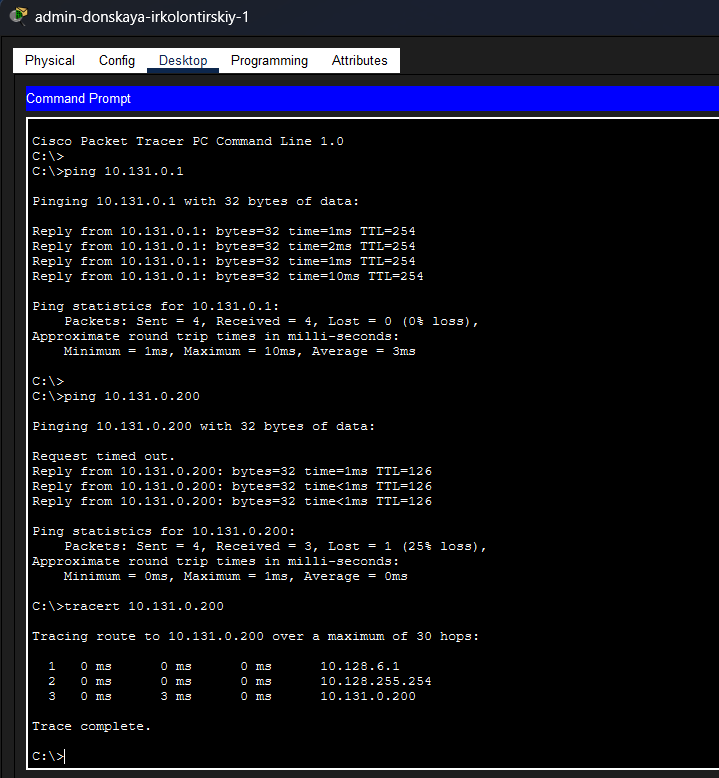

Проверка доступности шлюза и компьютера сети Университета г. Пиза

## Результат трассировки

Трассировка до узла **10.131.0.200** показала прохождение трафика через:

- **10.128.6.1** — первый маршрутизатор со стороны сети «Донская»;
- **10.128.255.254** — туннельный адрес маршрутизатора Университета г. Пиза;
- **10.131.0.200** — конечный узел сети университета.

Наличие адреса **10.128.255.254** подтверждает прохождение трафика через GRE-туннель.

# Проверка туннеля и маршрутизации

## Состояние туннеля на стороне сети «Донская»

Команда **show interface tunnel 0** показала состояние:

- **Tunnel0 is up**;
- **line protocol is up**.

Параметры туннеля:

- адрес Tunnel0 — **10.128.255.253/30**;
- tunnel source — **198.51.100.2**;
- tunnel destination — **192.0.2.20**;
- tunnel protocol — **GRE/IP**.

## Состояние туннеля на стороне сети «Донская»

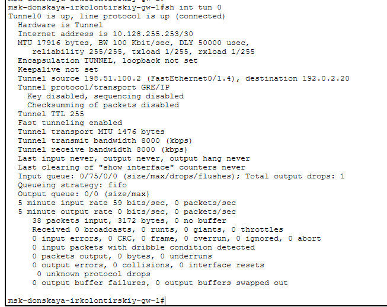

Проверка состояния GRE-туннеля на маршрутизаторе сети «Донская»

## Таблица маршрутизации сети «Донская»

В таблице маршрутизации маршрутизатора **msk-donskaya-irkolontirskiy-gw-1** присутствует маршрут:

- **10.131.0.0/24 via 10.128.255.254, Tunnel0**.

Маршрут получен через **OSPF**, поэтому удалённая сеть Университета г. Пиза доступна через GRE-туннель.

## Таблица маршрутизации сети «Донская»

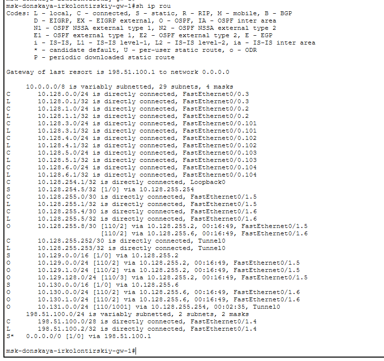

Таблица маршрутизации на маршрутизаторе сети «Донская»

## Состояние туннеля на стороне Университета г. Пиза

На маршрутизаторе **pisa-unipi-irkolontirskiy-gw-1** интерфейс **Tunnel0** также находится в состоянии **up/up**.

Параметры туннеля:

- адрес Tunnel0 — **10.128.255.254/30**;
- tunnel source — **192.0.2.20**;
- tunnel destination — **198.51.100.2**;
- tunnel protocol — **GRE/IP**.

## Состояние туннеля на стороне Университета г. Пиза

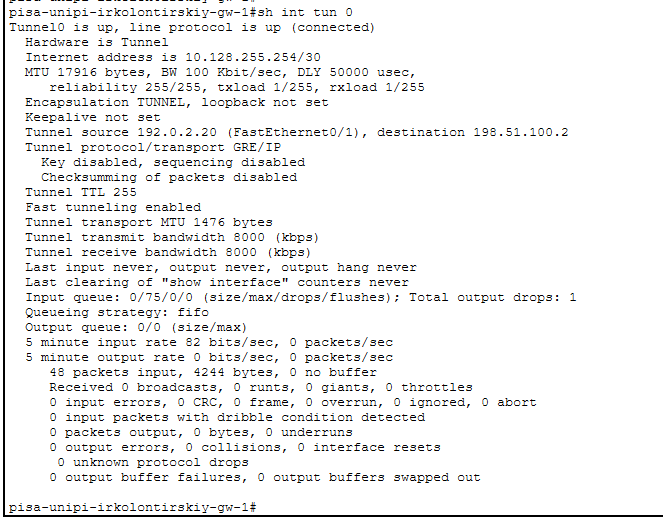

Проверка состояния GRE-туннеля на маршрутизаторе Университета г. Пиза

## Таблица маршрутизации Университета г. Пиза

В таблице маршрутизации присутствуют:

- **10.131.0.0/24** — локальная сеть университета;
- **10.128.255.252/30** — сеть GRE-туннеля;
- **192.0.2.0/24** — внешняя сеть маршрутизатора;
- OSPF-маршруты к удалённым сетям через **10.128.255.253**.

## Таблица маршрутизации Университета г. Пиза

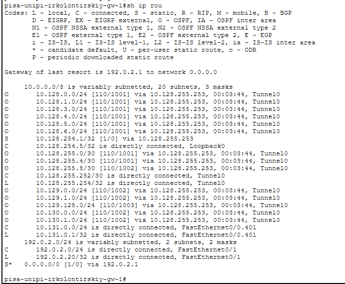

Таблица маршрутизации на маршрутизаторе Университета г. Пиза

# Выводы

## Вывод

В работе была настроена сеть Университета г. Пиза и организована связь с удалённой сетью «Донская».

Выполнены основные этапы:

- создана логическая и физическая схема сети;
- настроены коммутатор и маршрутизатор;
- создана VLAN **401**;
- настроен подинтерфейс **FastEthernet0/0.401**;
- создан GRE-туннель между площадками;
- включён обмен маршрутами через **OSPF**;
- проверена доступность шлюза и конечного узла сети Университета г. Пиза.